# Transcranial direct current stimulation of the right frontal eye field in a prosaccade task

Response time distribution model fits

Leon Reteig

# Reaction time distributions

R notebook for fitting parametric models of RT distributions in the `sacc-tDCS` dataset. Previous processing:

- Raw data were parsed into events (saccades, fixations, etc.) by the EyeLink data were collected on.
- Events were extracted and saccade measures were computed with a MATLAB script.

## Split data in equal blocks

We want the same number of trials to go into each distribution, so we’ll split the 30-minute long `post` leg into two. Then we have 4 15-minute long data segments: `pre`, `tDCS`, `post.1` and `post.2`.

```r
# Group single-trial data in 4 legs instead of 3
groupDataBlocked <- groupData %>%
  mutate(leg = as.character(leg)) %>% #un-factor the leg column so we can change it
  mutate(leg=replace(leg, leg == "post", "post.1"), # split the "post" level into two
         leg=replace(leg, block > 3, "post.2")) %>%
  mutate(leg = factor(leg, levels = c("pre","tDCS","post.1","post.2"))) #re-factor
```

## Fit the model

Next we fit an ex-gaussian distribution using the `retimes` package. One model is fit for each combination of:

- SUBJECT (S01, S02, etc.)
- STIMULATION (anodal, cathodal)
- LEG (pre, tDCS, post.1, post.2)
- TYPE (center, lateral)
- DIRECTION (left, right)

The ex-gaussian distribution is the convolution of a normal and an exponential distribution. It can be characterized with 3 parameters:

- $\mu$ (*mu*): the mean of the normal distribution
- $\sigma$ (*sigma*): the variance of the normal distribution
- $\tau$ (*tau*): the rate parameter of the exponential distribution

We’ll do minimal pre-processing: keep all subjects, only discard negative RTs

```r
groupDataFit <- groupDataBlocked %>%
  filter(latency > 0) %>% # throw out missing and negative RTs
  group_by(subject,stimulation,leg,type,direction) %>% # for every condition
  summarise(result = list(data.frame(t(attr(timefit(latency),"par"))))) %>% # [see below]
  ungroup() %>% # remove grouping information (otherwise unnest will not work)
  unnest() # unpack the list column, so each parameter gets its own column

# 1. fit the ex-gaussian to the latency data with the timefit() function
# 2. extract the fitted parameters from the resulting object with "attr()"
# 3. transpose ("t()") so every parameter is in a different column
# 4. convert to a data frame with one column per parameter
# 5. pack in a list so we have something of size 1 we can assign to the dataframe
# "result" is now a list-column, where each element is a dataframe with estimates of the 3 parameters
# Alternatively, create a function to fit the data, and then call it through dplyr::do
#myFunc <- function(x){
#  data.frame(t(attr(timefit(x),"par")))
#}
#groupDataFit <- groupDataBlocked %>%
#  group_by(subject,stimulation,leg,type,direction) %>% # for every condition
#  do((myFunc(.$latency)))
```

## Inspect fitted parameters

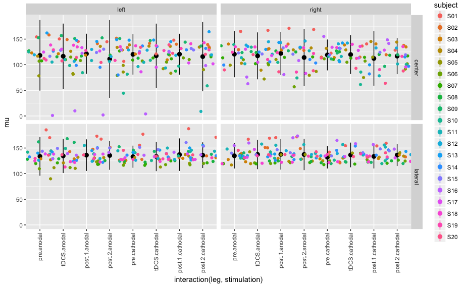

```r
ggplot(groupDataFit, aes(interaction(leg,stimulation), mu, color = subject)) +
  facet_grid(type~direction) +
  stat_summary(fun.y = mean, fun.ymin = function(x) mean(x) - 2*sd(x), fun.ymax = function(x) mean(x) + 2*sd(x), aes(group = 1)) + # plot mean and 2*SD to watch for outliers; we need group = 1 because the x-axis is a combination of factors
  geom_jitter(width = 0.6) +
  theme(axis.text.x = element_text(angle = 90, vjust = 0.5, hjust = 1))
```

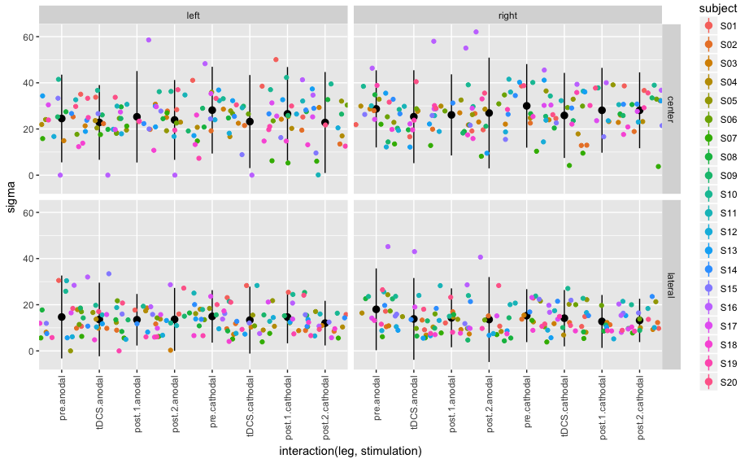

```r
ggplot(groupDataFit, aes(interaction(leg,stimulation), sigma, color = subject)) +
  facet_grid(type~direction) +
  stat_summary(fun.y = mean, fun.ymin = function(x) mean(x) - 2*sd(x), fun.ymax = function(x) mean(x) + 2*sd(x), aes(group = 1)) +
  geom_jitter(width = 0.6) +
  theme(axis.text.x = element_text(angle = 90, vjust = 0.5, hjust = 1))
```

Center saccades appear to have larger $\sigma$ than lateral. But if you inspect the distributions, the peak is actually much sharper, which should indicate lower variance. The problem is that the shape of many distributions does not conform well: many saccades are early and have little variance, but then there’s also a bump in the right-tail which causes the sigma-parameter to increase.

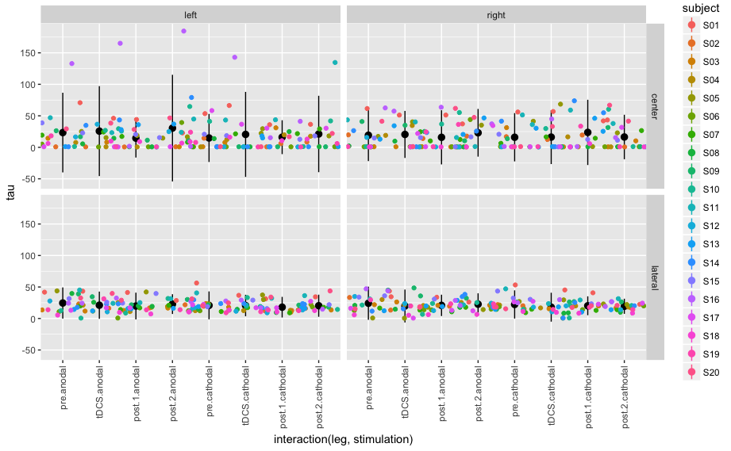

```r
ggplot(groupDataFit, aes(interaction(leg,stimulation), tau, color = subject)) +
  facet_grid(type~direction) +
  stat_summary(fun.y = mean, fun.ymin = function(x) mean(x) - 2*sd(x), fun.ymax = function(x) mean(x) + 2*sd(x), aes(group = 1)) +
  geom_jitter(width = 0.6) +
  theme(axis.text.x = element_text(angle = 90, vjust = 0.5, hjust = 1))
```

Particularly for center saccades, $\tau$ is many times estimated at 0. This means that the distribution is actually just a normal distribution. For center saccades that makes sense, as $\tau$ is responsible for the longer right tail that characterizes the ex-gaussian distribution. When saccades are all super fast, this tail is not present.

## Mu

### Plot

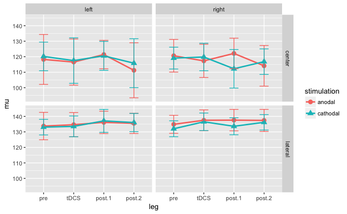

```r
muLinePlot <- ggplot(groupDataFit, aes(leg, mu, color = stimulation, shape = stimulation)) +
  facet_grid(type ~ direction) +
  stat_summary(fun.y = mean, geom = "point", size = 3) +
  stat_summary(fun.y = mean, geom = "line", aes(group = stimulation), size = 1) +
  stat_summary(fun.data = mean_cl_normal, geom = "errorbar", width = 0.3)
muLinePlot
```

### Statistics

#### Lateral

```r
muLateral <- groupDataFit %>%
  filter(type == "lateral") %>%
  select(-type)
```

```r
modelMuLateral <- ezANOVA(data = data.frame(muLateral), dv = .(mu), wid = .(subject), within = .(stimulation, leg, direction), type = 3)
```

Converting “subject” to factor for ANOVA.Converting “stimulation” to factor for ANOVA.Converting “direction” to factor for ANOVA.

```r
kable(modelMuLateral$ANOVA)
```

|  | Effect | DFn | DFd | F | p | p<.05 | ges |
| --- | --- | --- | --- | --- | --- | --- | --- |
| 2 | stimulation | 1 | 19 | 0.4962574 | 0.4896947 |  | 0.0018185 |
| 3 | leg | 3 | 57 | 4.0770965 | 0.0108122 | * | 0.0068828 |
| 4 | direction | 1 | 19 | 0.0862917 | 0.7721303 |  | 0.0007264 |
| 5 | stimulation:leg | 3 | 57 | 0.2632381 | 0.8515909 |  | 0.0003878 |
| 6 | stimulation:direction | 1 | 19 | 2.4797673 | 0.1318238 |  | 0.0016080 |
| 7 | leg:direction | 3 | 57 | 3.7885316 | 0.0150864 | * | 0.0027886 |
| 8 | stimulation:leg:direction | 3 | 57 | 1.1099797 | 0.3526354 |  | 0.0010857 |

```r
bfMuLateral = anovaBF(mu~stimulation*leg*direction+subject, data = data.frame(muLateral), whichModels="top", whichRandom = "subject", progress = FALSE, iterations = 100000) # compute Bayes Factors
```

[output not shown]

#### Center

## Sigma

### Plot

### Statistics

#### Lateral

#### Center

## Tau

### Plot

### Statistics

#### Lateral

#### Center